# L3 Raster data

2024-01-22

(Install and) load geodata library for geographical data. The geodata package facilitates access to climate, elevation, soil, crop, species occurrence, and administrative boundary data, and is a successor of the getData() function from the raster package. More info see [https://github.com/rspatial/geodata]

Install package terra and load it. Note geodata depends on terra. Version required: R (>= 3.5.0), terra (>= 1.6.41).

```r
#install.packages("geodata")
#install.packages("terra")
library(geodata)
```

use the worldclim_country() function of the geodata package (Hijmans et al. 2023) to download global temperature data from the WorldClim database. The function for WorldClim downloads monthly average climate data.

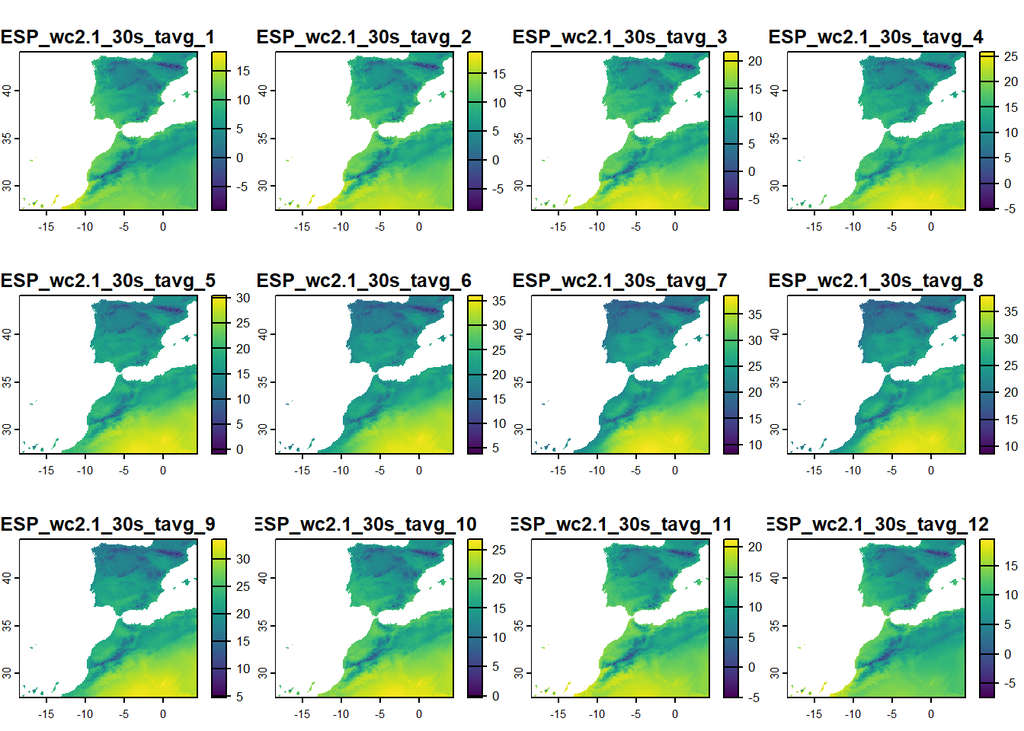

```r
library(terra)
r <- geodata::worldclim_country(country = "Spain", var = "tavg",
                                res = 100, path = tempdir())

# monthly average temperature in degree Celsius by specifying the country (country = "Spain"), the variable mean temperature (var = "tavg"), the resolution (res = 100), and the path where to download the data to as a temporary file (path = tempdir()). Figure 4.2 shows maps of the monthly average temperature in Spain.
plot(r)
```

```r
r
```

```
## class       : SpatRaster
## dimensions  : 1980, 2760, 12  (nrow, ncol, nlyr)
## resolution  : 0.008333333, 0.008333333  (x, y)
## extent      : -18.5, 4.5, 27.5, 44  (xmin, xmax, ymin, ymax)
## coord. ref. : lon/lat WGS 84 (EPSG:4326)
## source      : ESP_wc2.1_30s_tavg.tif
## names       : ESP_w~avg_1, ESP_w~avg_2, ESP_w~avg_3, ESP_w~avg_4, ESP_w~avg_5, ESP_w~avg_6, ...
## min values  :        -9.8,        -9.4,        -7.7,          -6,        -1.4,         3.2, ...
## max values  :        19.2,        18.9,        21.6,          26,        30.4,        36.0, ...
```

average over layers (months)

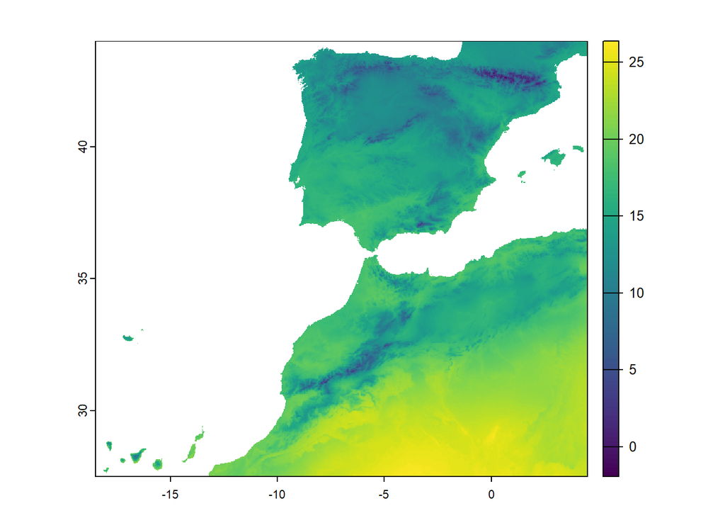

```r
r <- mean(r)
plot(r)
```

remember the “world” sf data we used last lecture, we can get the extent of Spain.

```r
library(spData)
library(sf)
names(world)
```

```
##  [1] "iso_a2"    "name_long" "continent" "region_un" "subregion" "type"
##  [7] "area_km2"  "pop"       "lifeExp"   "gdpPercap" "geom"
```

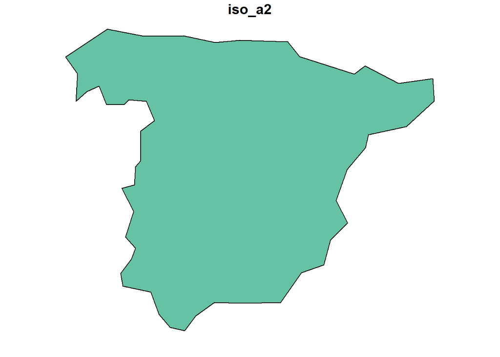

```r
spain1 = world[world$name_long == "Spain", 1 ]

plot(spain1)
```

get the extent and use crop() to remove the part of the raster that is outside the spatial extent

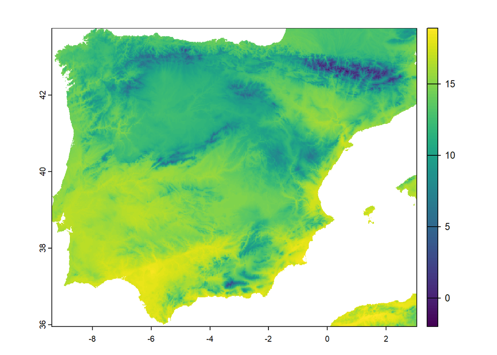

```r
sextent <- terra::ext(spain1)
r <- terra::crop(r, sextent)
plot(r)
```

We can use the mask() function to convert all values outside the map to NA

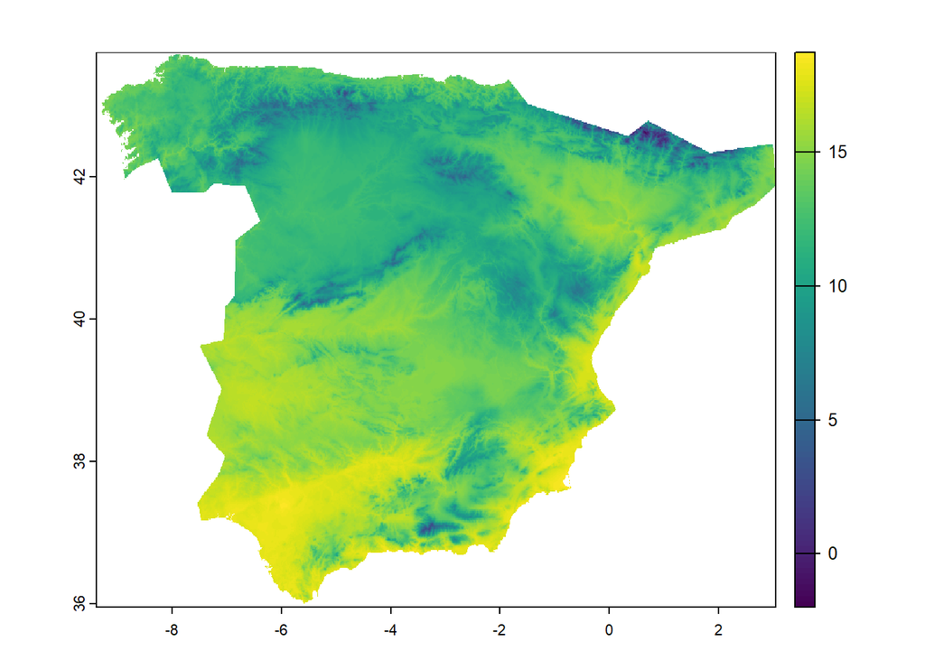

```r
# Masking
r <- terra::mask(r, vect(spain1))
plot(r)
```

Aggregate groups of cells of a raster to create a new raster with a lower resolution (i.e., larger cells)

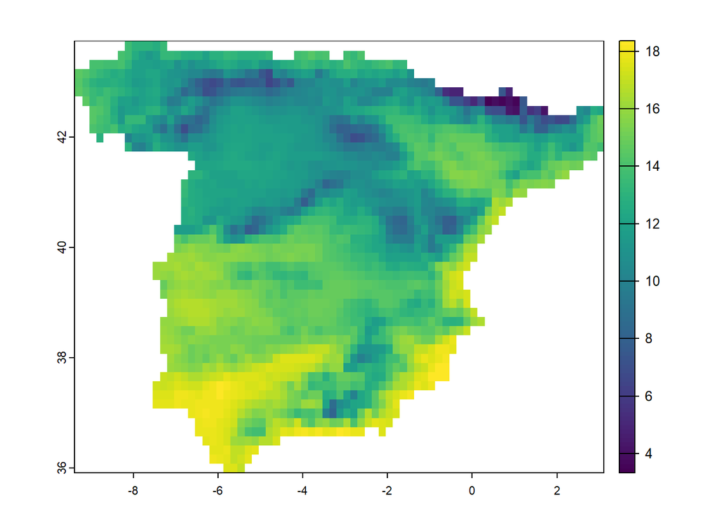

```r
coarser <- terra::aggregate(r, fact = 20, fun = "mean", na.rm = TRUE)
plot(coarser)
```

Read your own “.tif” or “.shp” files

```r
system.file("ex/elev.tif", package = "terra") # the directory of a file, here is an example using a file that is downloaded once you downloaded the package
```

```
## [1] "C:/Users/bt307587/AppData/Local/R/win-library/4.4/terra/ex/elev.tif"
```

```r
fras =rast(system.file("ex/elev.tif", package = "terra"))
fras
```

```
## class       : SpatRaster
## dimensions  : 90, 95, 1  (nrow, ncol, nlyr)
## resolution  : 0.008333333, 0.008333333  (x, y)
## extent      : 5.741667, 6.533333, 49.44167, 50.19167  (xmin, xmax, ymin, ymax)
## coord. ref. : lon/lat WGS 84 (EPSG:4326)
## source      : elev.tif
## name        : elevation
## min value   :       141
## max value   :       547
```

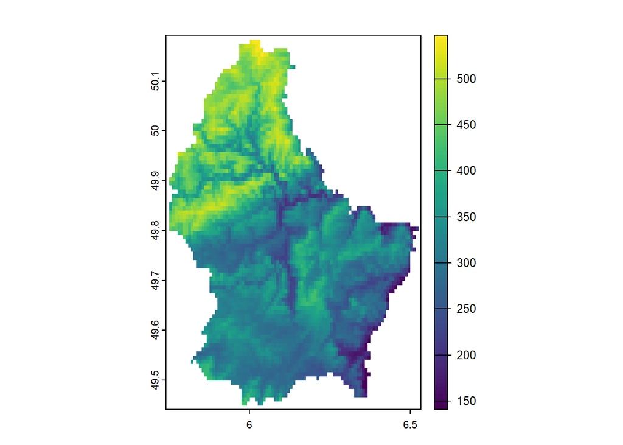

```r
plot(fras)
```

Reading a vector (here shapefile) file.

```r
fvec =vect(system.file("ex/lux.shp", package = "terra"))
fvec
```

```
##  class       : SpatVector
##  geometry    : polygons
##  dimensions  : 12, 6  (geometries, attributes)
##  extent      : 5.74414, 6.528252, 49.44781, 50.18162  (xmin, xmax, ymin, ymax)
##  source      : lux.shp
##  coord. ref. : lon/lat WGS 84 (EPSG:4326)
##  names       :  ID_1   NAME_1  ID_2   NAME_2  AREA       POP
##  type        : <num>    <chr> <num>    <chr> <num>     <num>
##  values      :     1 Diekirch     1 Clervaux   312 1.808e+04
##                    1 Diekirch     2 Diekirch   218 3.254e+04
##                    1 Diekirch     3  Redange   259 1.866e+04
```

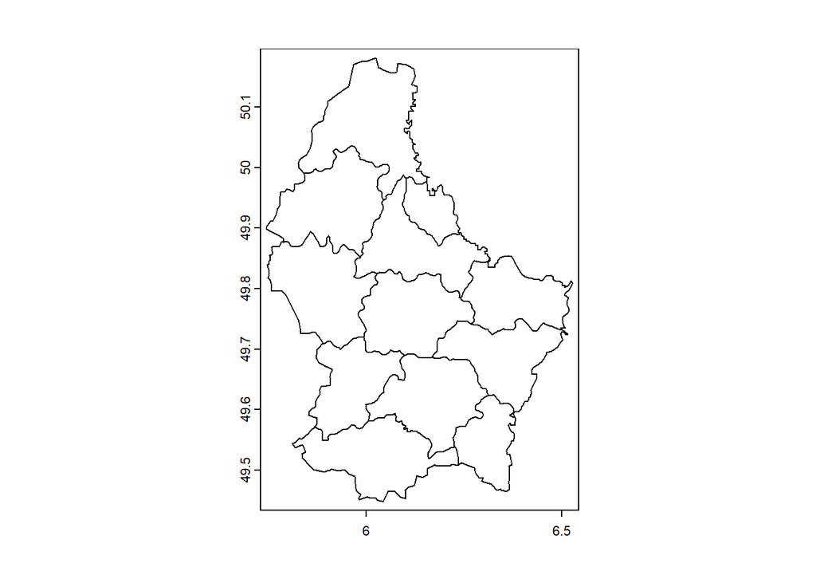

```r
plot(fvec)
```

Obtain the centroids of the division polygons, and their coordinates.

```r
centroids(fvec)
```

```
##  class       : SpatVector
##  geometry    : points
##  dimensions  : 12, 6  (geometries, attributes)
##  extent      : 5.886502, 6.378449, 49.52331, 50.07064  (xmin, xmax, ymin, ymax)
##  coord. ref. : lon/lat WGS 84 (EPSG:4326)
##  names       :  ID_1   NAME_1  ID_2   NAME_2  AREA       POP
##  type        : <num>    <chr> <num>    <chr> <num>     <num>
##  values      :     1 Diekirch     1 Clervaux   312 1.808e+04
##                    1 Diekirch     2 Diekirch   218 3.254e+04
##                    1 Diekirch     3  Redange   259 1.866e+04
```

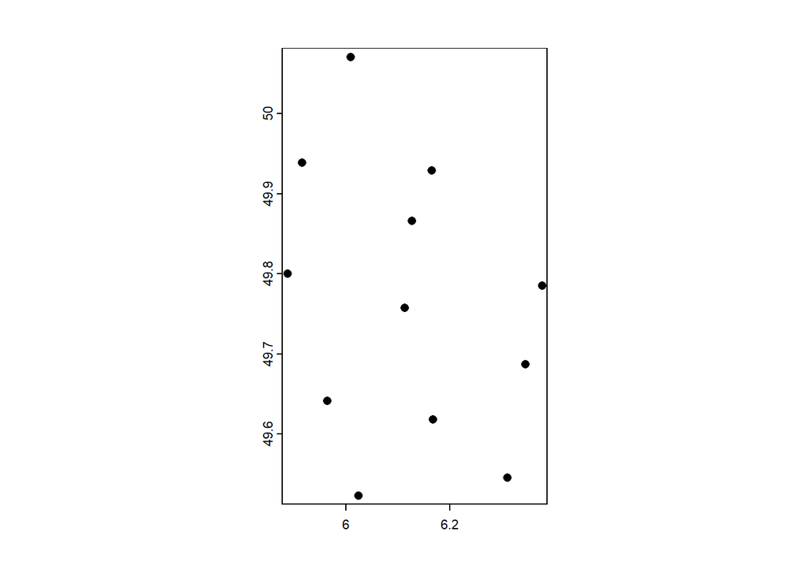

```r
plot(centroids(fvec))
```